# Chapter 6.2 - The Haunted DAG & The Causal Terror

```r
knitr::opts_chunk$set(fig.width=5, fig.height=2.5)
library(rcartocolor)
library(tidyverse)
library(magrittr)
library(brms)
library(tidybayes)
library(bayesplot)
library(dagitty)
devtools::load_all()
```

```
Loading rethinkingmooc
```

```r
colour_theme <- "BurgYl"
palette <- carto_pal(7, colour_theme)
```

Causality and correlation are hard to disentangle. For example, `Berkson's Paradox`, also known as *selection-distortion effect*, shows us that bad restaraunts in bad locations usually close down but have a chance to survive in good locations therefore biasing the set of observations we have available to us.

# Multicollinearity

Multicollinearity means strong correlation between two or more predictor variables. This can make the two variables effect measurements diffuse in the posterior. Recall that the coefficients in a multivate regression tell us the effect of a variable holding the rest still. As an example, leg length is indicative of height but if we already know the right legs length the left legs length won’t give us much extra information.

We’ll show this with the primate milk dataset, which is highly correlated. In general, primates with high sugar in their milk feed often while high fat feed infrequently.

```r
library(rethinking)
data(milk)
df <- as_data_frame(milk)
detach("package:rethinking", unload = TRUE)

df %<>%
  mutate(kcal.per.g = scale(kcal.per.g),
         perc.fat = scale(perc.fat),
         perc.lactose = scale(perc.lactose))

df %>%
  select(kcal.per.g, perc.fat, perc.lactose) %>%
  cor
```

```
             kcal.per.g   perc.fat perc.lactose
kcal.per.g    1.0000000  0.8869434   -0.9211182
perc.fat      0.8869434  1.0000000   -0.9416373
perc.lactose -0.9211182 -0.9416373    1.0000000
```

```r
fit_6.5 <- brm(kcal.per.g ~ 1 + perc.fat + perc.lactose,
    data = df, family = gaussian,
    prior = c(prior(normal(0, .2), class = "Intercept"),
              prior(normal(0, .5), coef = "perc.fat"),
              prior(normal(0, .5), coef = "perc.lactose"),
              prior(exponential(1), class = "sigma")))
fit_6.5
```

```
 Family: gaussian
  Links: mu = identity; sigma = identity
Formula: kcal.per.g ~ 1 + perc.fat + perc.lactose
   Data: df (Number of observations: 29)
Samples: 4 chains, each with iter = 2000; warmup = 1000; thin = 1;
         total post-warmup samples = 4000

Population-Level Effects:
             Estimate Est.Error l-95% CI u-95% CI Eff.Sample Rhat
Intercept       -0.00      0.07    -0.14     0.14       3085 1.00
perc.fat         0.26      0.19    -0.12     0.63       2157 1.00
perc.lactose    -0.66      0.19    -1.04    -0.29       2177 1.00

Family Specific Parameters:
      Estimate Est.Error l-95% CI u-95% CI Eff.Sample Rhat
sigma     0.41      0.06     0.31     0.56       2797 1.00

Samples were drawn using sampling(NUTS). For each parameter, Eff.Sample
is a crude measure of effective sample size, and Rhat is the potential
scale reduction factor on split chains (at convergence, Rhat = 1).
```

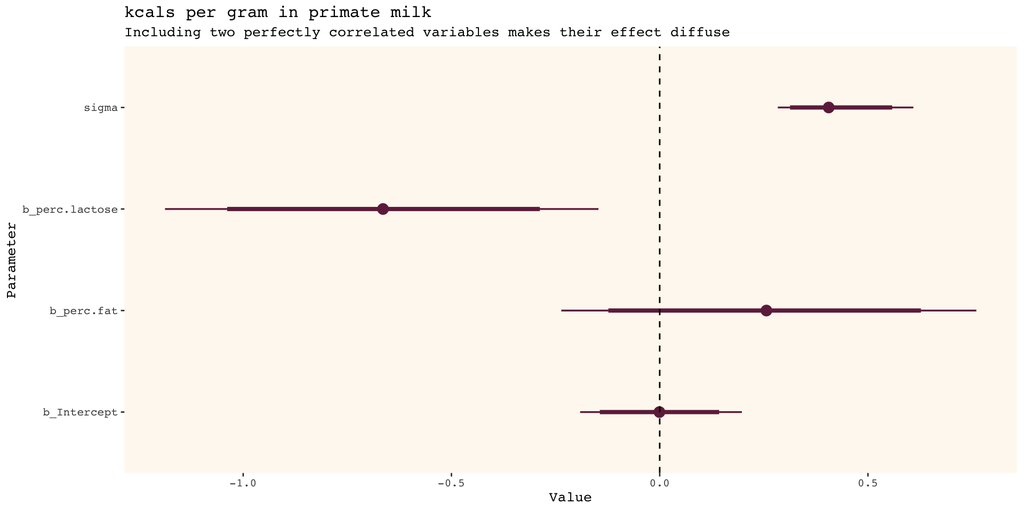

```r
fit_6.5 %>%
  gather_draws(`(^b_.*)|sigma`, regex = TRUE) %>%
  ggplot(aes(y=as_factor(.variable), x=.value)) +
    stat_pointintervalh(.width = c(.99, .95), colour = palette[7]) +
    geom_vline(xintercept = 0, linetype = 2) +
    theme_burgyl() + xlab("Value") + ylab("Parameter") +
    ggtitle("kcals per gram in primate milk",
            "Including two perfectly correlated variables makes their effect diffuse")
```

When you include two highly substitutable variables in a regression, the posterior distributin ends up describing a long ride of combinations between the two.

```r
fit_6.5 %>%
  spread_draws(`b_.*`, regex = TRUE) %>%
  select(starts_with("b_")) %>%
  cor
```

```
               b_Intercept b_perc.fat b_perc.lactose
b_Intercept     1.00000000 0.02307673     0.02409173
b_perc.fat      0.02307673 1.00000000     0.91627099
b_perc.lactose  0.02409173 0.91627099     1.00000000
```

You can’t always glean a solution to multicollinearity by examining a table of correlations. For example, other predictors might be correlated with only of the pair of correlated variables. There is no easy answer, we always need conceptual models based on scientific background to do useful statistics. The best course is to have a trusted causal model that tells you which variable to lean on. Sometimes, parameters are just *non-identifiable*.

# Post-treatment bias

This occurs when you include variables that are consequences of other variables. Fungus is a result of soil treatment. So once we already know whether or not there was fungus the choice of soil treatment doesn’t matter.

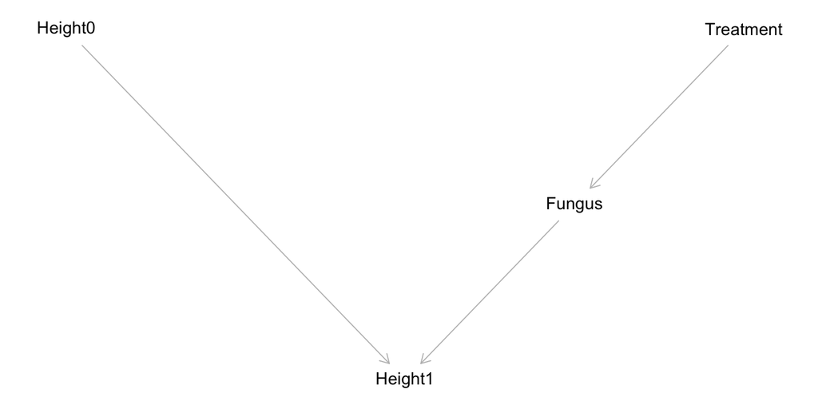

```r
impliedConditionalIndependencies( plant_dag )
```

```
Fungus _||_ Height0
Height0 _||_ Treatment
Height1 _||_ Treatment | Fungus
```

# Confronting confounding

Confounding is any context in which the association between an outcome Y and a predictor of interest X is not the same as it would be if we had experimentally determined the values of X. Directly manipulating a variable in a DAG removes everything pointing to it.

There are primarily four types of DAG relations.

1. The fork: `X <- Z -> Y`. After conditioning on $Z$, $X$ tells us nothing about $Y$.
2. The pipe: `X -> Z -> Y`. Conditioning on $Z$ blocks the path from $X$ to $Y$ so including it would shrink $X$’s coefficient. We often do not want this.
3. The collider: `X -> Z <- Y`. Incorporating $Z$ shows that there is no real relationship between $X$ and $Y$ if we actually removed sample selection bias.
4. Descendent variable: `X -> Z -> {Y, K}`. Conditioning on a descendent variable ($K$) is like conditioning on the variable itself but weaker.

Lets return to the waffle house example.

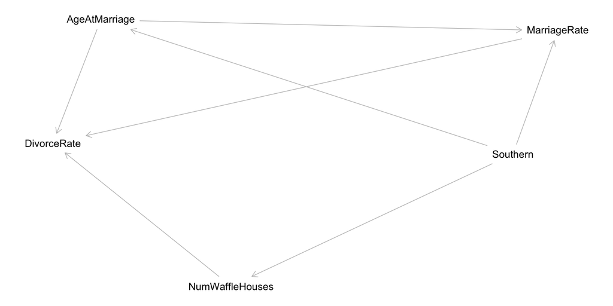

```r
dag_6.2 <- dagitty( "dag {
    Southern -> AgeAtMarriage -> DivorceRate
    Southern -> MarriageRate -> DivorceRate
    Southern -> NumWaffleHouses -> DivorceRate
    AgeAtMarriage -> MarriageRate
}")
plot(dagitty::graphLayout(dag_6.2))
```

We can ask dagitty to tell us how to control for a relationship. We need to add `southern` to the regression or both `AgeAtMarriage` and `MarriageRate`.

```r
adjustmentSets(dag_6.2, exposure = "NumWaffleHouses", outcome = "DivorceRate")
```

```
 { AgeAtMarriage, MarriageRate }
 { Southern }
```

But is the graph correct? We can take a look at the conditional independence that the DAG suggests.

```r
impliedConditionalIndependencies(dag_6.2)
```

```
AgeAtMarriage _||_ NumWaffleHouses | Southern
DivorceRate _||_ Southern | AgeAtMarriage, MarriageRate, NumWaffleHouses
MarriageRate _||_ NumWaffleHouses | Southern
```